# Your first predictions - Predicting Salaries 📈

## But first - a tutorial on `Jupyter Notebook` and `Python` basics 🚴‍♀️

### Jupyter Notebook 📝

Notebook consists of two main parts.

1. Text instructions like this one - these are made using a text formatting language called [Markdown](https://github.com/adam-p/markdown-here/wiki/Markdown-Cheatsheet)
2. Code cells like the one below:

```python
1 + 1 * 2
```

```
3
```

1. To run a code cell, click into it with your mouse and press the `► Run` button in the navbar at the top of the notebook.
2. You can also use the shortcut `Shift + Enter` to run a cell!
3. A cell that has been run will get a `In [number]` next to it
4. An output (returned value) of a cell will be displayed below with a `Out[number]` next to it
5. If you want to add another code cell - look for the `➕` button in the navbar.

```python
# you will have cells like these for you to code in
```

### 🐍Python basics

[**Python**](https://docs.python.org/) has been around since late 1980s. In fact, Machine Learning concept has been around since 1950s! 😯

But rapid advances in internet speed, data storage and the very active Python community has married the two things very well in the last 5 years.

In **Python** we have **built-in data types** to help us work with different kinds of data:

**Strings** (`str` in Python) for **literal text, column or file names**. Made by putting quotes (`""`) around the text.

```python
"hello!"
"ML like a pro"
```

```
'ML like a pro'
```

**Integers** (`int` in Python) for **whole numbers**

```python
42
-10
```

```
-10
```

**Floats** (`float` in Python) for **numbers with decimal points**. The decimal delimeter is always `.`

```python
3.14
```

```
3.14
```

These **numeric** types accept all standard math calculations:

```python
9 / 3
2 + 5
2 > 1
```

```
True
```

📦 We have **variables** to help store data:

```python
name = "Alan Turing"
age = 42
new_employee_data = [0, 30, 3, 7.1, 12]
```

...and **re-use** it later!:

```python
"Hi, my name is " + name
```

```
'Hi, my name is Alan Turing'
```

```python
# getting one year older :(
age = 16 + 1
age
```

```
17
```

💥And we have **methods** to perform actions on data:

```python
name.upper()
```

```
'ALAN TURING'
```

```python
number_of_n = name.count('n') # creating a new variable as a result of the method call
number_of_n
```

```
2
```

### 1. Your turn! 🚀

Practice using some of the basic types we just covered. Here are some ideas:

- Create two strings and add them together with a `+` sign
- Create a variable with your age in years, then count your age in hours (roughly)
- Check if your birth month number is higher than (`>`) than your birth day number
- Create a variable with your full name, then tell yourself that you rock in all caps! 💪 (ie. `"YOU ROCK ALAN TURING!"`)

```python
# your code here
age_in_years = 16
age_in_hours = print(age*365*24)
```

[output not shown]

Don't worry if some things feel unnatural at first - you are learning a new language in just 20 minutes! 💪

# Let's get back into Data Science 🤖

1. Run below cell to `import` some Python libraries - these will be our tools for working with data 📊

```python
import pandas as pd
import numpy as np
import seaborn as sns
```

1. Run below cell to read the `CSV` file into a `DataFrame` - a format that is great for data analysis inside Python!

*Note: the datasets is cleaned and federated for learning purposes*

```python
salaries = pd.read_csv('clean_data/salaries.csv')
salaries
```

|  | Gender | Age | Department | Department_code | Years_exp | Tenure (months) | Gross |
| --- | --- | --- | --- | --- | --- | --- | --- |
| 0 | 0 | 25 | Tech | 7 | 7.5 | 7 | 74922 |
| 1 | 1 | 26 | Operations | 3 | 8.0 | 6 | 44375 |
| 2 | 0 | 24 | Operations | 3 | 7.0 | 8 | 82263 |
| 3 | 0 | 26 | Operations | 3 | 8.0 | 6 | 44375 |
| 4 | 0 | 29 | Engineering | 0 | 9.5 | 25 | 235405 |
| ... | ... | ... | ... | ... | ... | ... | ... |
| 1797 | 0 | 29 | Other | 4 | 9.5 | 34 | 88934 |
| 1798 | 0 | 27 | Engineering | 0 | 8.5 | 33 | 133224 |
| 1799 | 0 | 29 | Operations | 3 | 9.5 | 15 | 72547 |
| 1800 | 0 | 47 | Other | 4 | 18.5 | 30 | 227176 |
| 1801 | 0 | 27 | Finance | 1 | 8.5 | 29 | 114641 |

1802 rows × 7 columns

## We can get a lot of insight without ML! 🤔

### 2. Your turn! 🚀

Let's start by **understanding the data we have** - how big is the dataset, what is the information (columns) we have and so on:

**💡 Tip:** remember to check the slides for the right methods ;)

```python
# your code here
round(salaries.describe())
```

|  | Gender | Age | Department_code | Years_exp | Tenure (months) | Gross |
| --- | --- | --- | --- | --- | --- | --- |
| count | 1802.0 | 1802.0 | 1802.0 | 1802.0 | 1802.0 | 1802.0 |
| mean | 0.0 | 32.0 | 4.0 | 11.0 | 48.0 | 175827.0 |
| std | 0.0 | 5.0 | 2.0 | 3.0 | 36.0 | 105513.0 |
| min | 0.0 | 21.0 | 0.0 | 6.0 | 6.0 | 256.0 |
| 25% | 0.0 | 28.0 | 2.0 | 9.0 | 23.0 | 104217.0 |
| 50% | 0.0 | 31.0 | 4.0 | 10.0 | 39.0 | 150330.0 |
| 75% | 1.0 | 35.0 | 7.0 | 12.0 | 66.0 | 221136.0 |
| max | 1.0 | 56.0 | 7.0 | 23.0 | 190.0 | 1024965.0 |

**Reveal Solution 🙈**

```
salaries.shape # to see how many rows, columns
salaries.dtypes # to see available columns and their data type
round(salaries.describe()) # to see a readable summary about the dataset, like averages, minimums and maximums
```

Now try to **separate only some columns** - say we only want to see departments, or departments and salaries:

```python
# your code here
salaries[["Department", "Gross"]]
```

|  | Department | Gross |
| --- | --- | --- |
| 0 | Tech | 74922 |
| 1 | Operations | 44375 |
| 2 | Operations | 82263 |
| 3 | Operations | 44375 |
| 4 | Engineering | 235405 |
| ... | ... | ... |
| 1797 | Other | 88934 |
| 1798 | Engineering | 133224 |
| 1799 | Operations | 72547 |
| 1800 | Other | 227176 |
| 1801 | Finance | 114641 |

1802 rows × 2 columns

**Reveal Solution 🙈**

```
salaries["Department"] # to see one column
salaries[["Department", "Gross"]] # double bracket if we want to see multiple columns
```

### 3. Your turn - Now let's do some **visualization** 📊.

Let's follow some basic intuition - **does years of experience affect gross salary❓**

Let's use a [Seaborn Scatterplot](https://seaborn.pydata.org/generated/seaborn.scatterplot.html) - a method inside the Seaborn library (which we imported above and shortened to `sns`) that gives us a graph with data points as dots with `x` and `y` values.

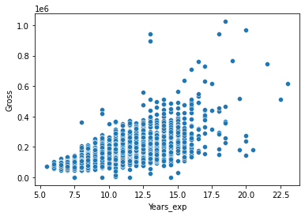

```python
# your code here
# male is 0 and female is 1
sns.scatterplot(data=salaries, x="Years_exp", y="Gross")
```

**Reveal Solution 🙈**

```
sns.scatterplot(data=salaries, x="Years_exp", y="Gross")
```

Remember one of the questions from the slides - **do women and men earn equally in this example❓**

*Note: 'Male' is coded as 0, 'Female' - as 1*

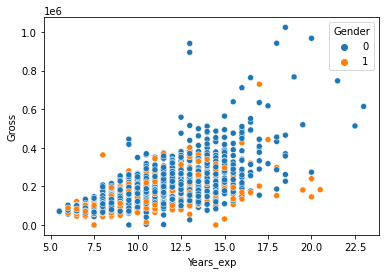

```python
# your code here
sns.scatterplot(data=salaries, x="Years_exp", y="Gross", hue="Gender")
```

**Reveal Solution 🙈**

```
sns.scatterplot(data=salaries, x="Years_exp", y="Gross", hue="Gender")
```

Let's also understand the **number of** some data points we have - how many women and men? How many in each department? Seaborn `countplot` is here to help with that.

**💡 Tip:** you can always call methods `.dtypes` or `.columns` on your dataset to check what columns you have.

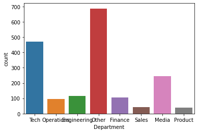

```python
# your code here
sns.countplot(data=salaries, x="Department")
```

**Reveal Solution 🙈**

```
sns.countplot(data=salaries, x="Gender") # to see how many of each gender we have in the dataset
sns.countplot(data=salaries, x="Department") # to see how many of each department we have
```

**Bonus question:** can you visualize **how many men and women there are per department**? 🤔 A `hue` might help...

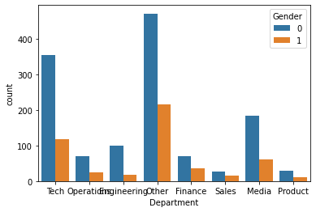

```python
# your code here
sns.countplot(data=salaries, x="Department", hue="Gender")
```

**Reveal Solution 🙈**

```
sns.countplot(data=salaries, x="Department", hue="Gender")
```

#### 🥈*A good data expert knows all the most complex models.*

### 🥇*A great data expert knows when results can be achieved without them.*

## Your first model - Linear Regression 📈

**1.** First, let's create what will be our...

- Features and target
- Inputs and output
- X and Y

```python
# your code here
target= salaries["Gross"]
target
```

```
0        74922
1        44375
2        82263
3        44375
4       235405
         ...
1797     88934
1798    133224
1799     72547
1800    227176
1801    114641
Name: Gross, Length: 1802, dtype: int64
```

**Reveal Solution 🙈**

```
features = salaries.drop(["Gross", "Department"], axis="columns") # dropping the Department column because it's text
target = salaries["Gross"]
```

Feel free to check what is in your `features` and `target` below:

```python
# your code here
features= salaries.drop(["Gross","Department"],axis="columns")
features
```

|  | Gender | Age | Department_code | Years_exp | Tenure (months) |
| --- | --- | --- | --- | --- | --- |
| 0 | 0 | 25 | 7 | 7.5 | 7 |
| 1 | 1 | 26 | 3 | 8.0 | 6 |
| 2 | 0 | 24 | 3 | 7.0 | 8 |
| 3 | 0 | 26 | 3 | 8.0 | 6 |
| 4 | 0 | 29 | 0 | 9.5 | 25 |
| ... | ... | ... | ... | ... | ... |
| 1797 | 0 | 29 | 4 | 9.5 | 34 |
| 1798 | 0 | 27 | 0 | 8.5 | 33 |
| 1799 | 0 | 29 | 3 | 9.5 | 15 |
| 1800 | 0 | 47 | 4 | 18.5 | 30 |
| 1801 | 0 | 27 | 1 | 8.5 | 29 |

1802 rows × 5 columns

**2.** Time to **import** the Linear Regression model

Python libraries like [Scikit-learn](https://scikit-learn.org/0.21/modules/classes.html) make it super easy for people getting into Data Science and ML to experiment.

The code is already in the library, it's just about **calling the right methods!** 🛠

```python
# your code here
from sklearn.linear_model import LinearRegression
```

**Reveal Solution 🙈**

```
from sklearn.linear_model import LinearRegression
```

Now to **initialize** the model

```python
# your code here
linear_model = LinearRegression()
```

**Reveal Solution 🙈**

```
model = LinearRegression()
```

**3.** We **train** the model.

This is the process where the Linear Regression model looks for a line that best fits all the points in the dataset. This is the part where the computer is hard at work **learning**! 🤖

```python
# your code here
linear_model.fit(features,target)
```

```
LinearRegression()
```

**Reveal Solution 🙈**

```
model.fit(features, target)
```

**4.** We **score** the model

Models can have different default scoring metrics. Linear Regression by default uses something called `R-squared` - a metric that shows how much of change in the target (Gross salary) can be explained by the changes in features (Age, Tenure, Gender etc.)

```python
# your code here
linear_model.score(features, target)
```

```
0.43754799942321354
```

**Reveal Solution 🙈**

```
model.score(features, target)
```

⚠️ **Careful not to confuse this with accuracy**. The above number is shows that **"the inputs we have can help us predict around 40-45% of change in the salary"** Which is decent considering we did this in 10 min!

**5.** Let's **predict** the salary of a new hire 🔮

*Note: here is a reminder of the columns in the table:* `['Gender', 'Age', 'Department_code', 'Years_exp', 'Tenure (months)']`

```python
# here's a freebie! You can change the numbers below to change the info of your hire ;)
hire = [[0, 29, 2, 5.2, 10]]

# your code here
linear_model.predict(hire)
```

```
array([117918.74200579])
```

**Reveal Solution 🙈**

```
model.predict(hire)
```

💡 A hint for **departments and their codes**:

- Engineering - 0
- Finance - 1
- Media - 2
- Operations - 3
- Other - 4
- Product - 5
- Sales - 6
- Tech - 7

**6.** **Explaining** the model

There is a whole concept called [**Explainable AI (XAI)**](https://arxiv.org/abs/2006.00093) which is rising in popularity, as the widespread application of machine learning, particularly deep learning, has led to the development of highly accurate models but **models lack explainability and interpretability**.

Luckily, Linear Regression is a [linear model](https://scikit-learn.org/stable/modules/linear_model.html), so it's explainability is quite high.

**6.1.** We can check the `coef_` or the **coefficients** of the model. These explain how much the target (Gross salary) changes with a change of `1` in each of the features (inputs), while holding other features constant.

```python
# your code here
linear_model.coef_
```

```
array([-24245.70669339,   9467.18023663,   2351.48450104,   4733.59011832,
          249.19491939])
```

**Reveal Solution 🙈**

```
model.coef_
```

🤔 We'd need to check the column order again, to know which number is which input. But, **we got you covered!** Run the cell below:

```python
pd.concat([pd.DataFrame(features.columns),pd.DataFrame(np.transpose(linear_model.coef_))], axis = 1)
```

|  | 0 | 0 |
| --- | --- | --- |
| 0 | Gender | -24245.706693 |
| 1 | Age | 9467.180237 |
| 2 | Department_code | 2351.484501 |
| 3 | Years_exp | 4733.590118 |
| 4 | Tenure (months) | 249.194919 |

**6.2** The other thing we can check is the **intercept** of the model. This is the target (Gross salary) for when all inputs are 0. So imagine a newborn baby going to the office:

```python
# your code here
linear_model.intercept_
```

```
-188439.07166781538
```

**Reveal Solution 🙈**

```
model.intercept_
```

# Congratulations, you are a Linear Regression wizzard! 🧙‍♀️🧙‍♂️

- You can try to play around with the `hire` variable to see the `.predict`ion results
- You can also try to change the `features` variable - try removing more columns!
- Looking for a bigger challenge? 🏋️‍♀️ Go to the **optional challenge `2. KNN - Customer Churn`** to explore another model type